# Implementing Vehicle Safety Standards Reduces Rates of Road Mortality Worldwide

Introduction to Data Science* *University of Nebraska Omaha

December 12, 2018

Abstract

Each year, an estimated 1.3 million people die in car accidents around the world, and 20 to 50 million more sustain injuries. In this project, we explore factors that affect road transportation safety. We examine correlations between road casulaties and four contributing factors: speed limit laws, vehicle safety standards, transportation infrastructure spending, and road congestion. We create data products exploring the relationships between each of these variables and death statistics. The first data product is a set of maps comparing death rates with maximum speed limits per country. A second set of maps depicts relationships between road deaths and vehicle safety standards. A third set of maps compares death rates with adherence road infrastructure investmentspending. A fourth set of maps examines rates of road congestion as a possible cause road injuries. All four sets of maps provide insights in understanding the factors that contribute to road deaths.

# 1 Introduction

As the world advances more in a technological aspect, cars have gained multiple features to make them safer to drive. However, this still does not completely mitigate the fact that the roads are still dangerous due to multiple other circumstances. It is important for drivers to understand the factors that could cause these fatal car crashes in order to possibly avoid them in the future. We will investigate the possible cause of road accidents by drawing from multiple different data sets. This project hopes to illuminate some of the factors that may hint in the right direction of more road safety around the world. Nevertheless, the data that we are looking at includes more correlations than true fact. Each and every one of these data sets can be seen as a cause of the accidents but with just removing or increasing the one factor will not completely erase the risk and associated death toll. It may improve road safety but we can see some of the preventable causes of these fatal accidents.

# 2 Explanation of the Data

Data used in this project correspond to four factors related to road vehicle travel: maximum speed limits, vehicle safety standards, road infrastructure investment, and road congestion. The research team weighed the inclusion of several other factors, such as rates of vehicle ownership, costs of driver registration, seatbelt laws, blood-alcohol content laws, and emergency response times. The four selected factors were chosen as the most appropriate representatives respective to four general aspects of vehicle travel that could impact death rates: driver behavior, vehicle design, road quality, and traffic environment. Road deaths are used in favor of road injury accidents based on the assumption that death data is more consistent due to underreporting of other types of injuries.

## 2.1 Obtaining and Preparing the Data

Data for road deaths and two of the variables–speed limits and vehicle safety standards–come from a study published by the World Health Organization (WHO) [1]. The study included data from 2013 and includes nearly very country in the world. Data for the other two variables–road infrastructure investment per capita and passenger-kilometers traveled–come from the International Transportation Forum (ITF) of the Organization for Economic Co-operation and Development [2]. The ITF data cover 59 countries in Europe, North America, Asia, and Oceania. The ITF has annual statistics from recent decades. For this study, figures from 2013 were chosen for compatibility to the WHO data. Finally, the ITF statistics for passenger-kilometers traveled were used in tandem with the CIA World Factbook’s figures on total kilometers of road per country [3]. The ratio of passenger-km per km of road provides a reasonable method for estimating the density of road travelers.

All data are available from the websites of the WHO, the ITF, or the CIA. The WHO and ITF data are exportable in CSV format. Those data are read into R and columns representing the relevant variables selected with minimal manipulation. The WHO speed limit data list values for urban and rural speed limits. This study utilizes the rural values, which were invariably equal to or greater than the urban values. The WHO vehicle safety data has columns for seven distinct vehicle safety regulations, with each row (country) listed as a “yes” or a “no” for each regulation. After replacing “yes” and “no” with the boolean values 1 and 0, this dataframe was aggregated so that a value between 0 and 7 was associated with each country to represent the number of vehicle safety standards in place. For the ITF data, values for all years other than 2013 were removed.

The CIA data is downloadable in TXT format and requires additional cleaning to arrange appropriate columns representing “country” and “km of road.” As described in Section 2, the km of road values were combined with passenger-km figures from the ITF to create a measure of traffic congestion.

After modifying the format of country names to ensure that strings matched as appropriately, dataframes representing annual road deaths, maximum speed limits, aggregated safety standards, infrastructure investment, and congestion were merged to create a Road Mortality Factors dataframe for use in analysis.

|  | rural | aggregate | roadspending | congestion | deathsper100k |
| --- | --- | --- | --- | --- | --- |
| afghanistan | 90 | 0 | NA | NA | 15.5 |
| albania | 80 | 0 | 107 | 0.3008905 | 15.1 |
| algeria | 100 | 0 | NA | NA | 23.8 |
| andorra | 90 | 7 | NA | NA | 7.6 |
| angola | 90 | 0 | NA | NA | 26.9 |
| antiguaandbarbuda | 64 | 0 | NA | NA | 6.7 |

Figure 1: A subset of the Road Mortality Factors dataframe created for the project and used during analysis.

# 3 Products

## 3.1 Map Plots

Geographic information plays a crucial role in this project. Each country differs in the discrete aspects of road safety that we are analyzing. For instance, the amount of vehicle safety regulations and the amount of people on the road varies from country to country. Analyzing this information from the country level allows more insight to what could be causing these accidents and what rules we may be able to apply from other countries to make our roads at home safer. Through the use of color scales, maps allow for a visual representation of which country has the most fatal accidents and which factor might lend into the number.

## 3.2 Scatter Plots

For each of the studied variables, a scatter plot illustrates the relationship between the variable and rates of road mortalities. Each data point represents a country. A line of best fit is applied to each plot using a linear model method in the R package ‘ggplot2’.

## 3.3 Interactive App

An interactive application created using the R package ‘shiny’ allows the user to cycle through maps of the variables and compare them with maps of death rates for a visual understanding of the relationships. Along with these maps, each sheet includes a plot of the forty countries with the highest values of the subject variable.

# 4 Findings

After gathering and preparing data on maximum speed limits, vehicle safety standards, road infrastructure spending, and traffic congestion, the research group created a linear model incorporating all of the factors. A residuals plot (Figure 2) confirms the appropriateness of the model, and allows the group to draw conclusions from the data.

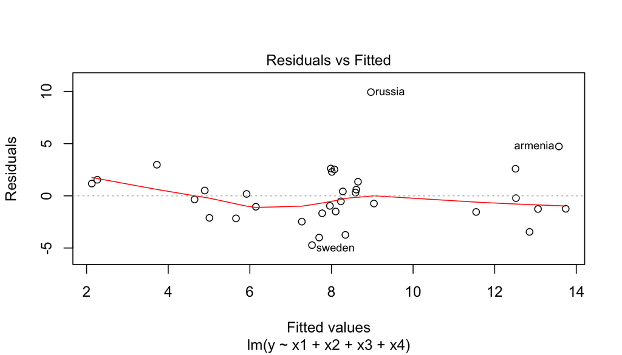

Figure 2: A residual plot of the Road Mortality Factors dataframe. Values “x1”, “x2”, “x3”, and “x4” correspond to speed limits, safety standards, infrastructure spending, and congestion. The plot shows that the linear model is appropriate in that there is no discernable pattern in the residuals.

The data show that the road mortality rates of a given country is affected by the number of vehicle safety standards the country has adopted and by per capita rates of road spending. Maximum speed limits and traffic congestion has little impact.

## 4.1 Road Deaths and Speed Limits

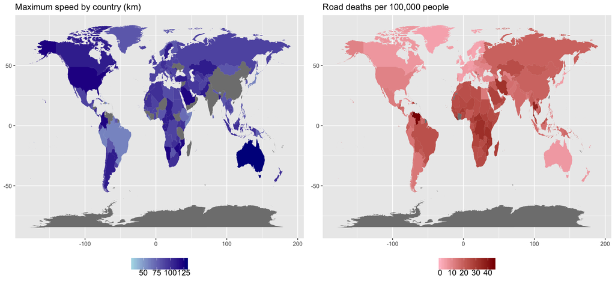

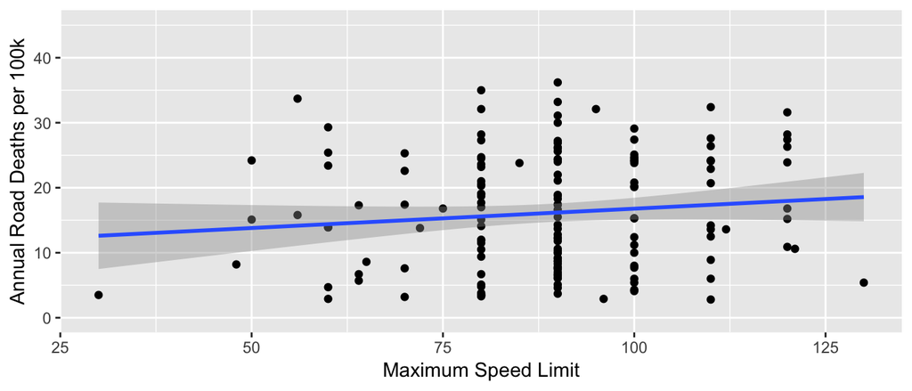

Figure 3: Top: Maps comparing maximum speed limit and rates of road death by country. Bottom: Scatter plot of speed limits versus mortality rates. Source: World Health Organization, 2013.

## 4.2 Road Deaths and Vehicle Safety Standards

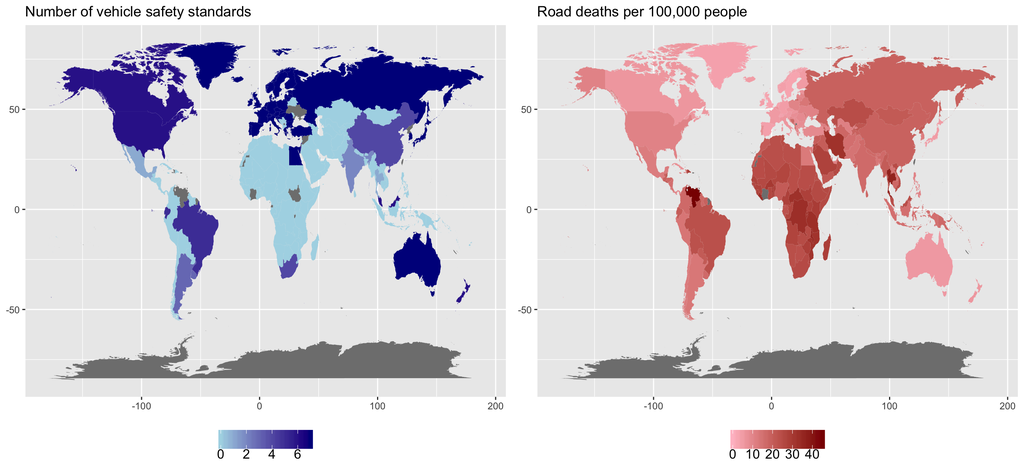

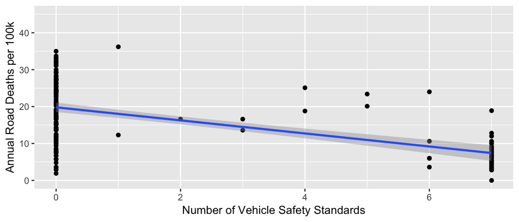

Figure 4: Top: Maps comparing number of vehicle safety standards and rates of road death by country. Bottom: Scatter plot of safety standards versus mortality rates. Source: World Health Organization, 2013.

## 4.3 Road Deaths and Road Infrastructure Spending

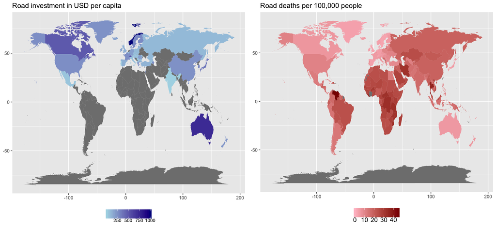

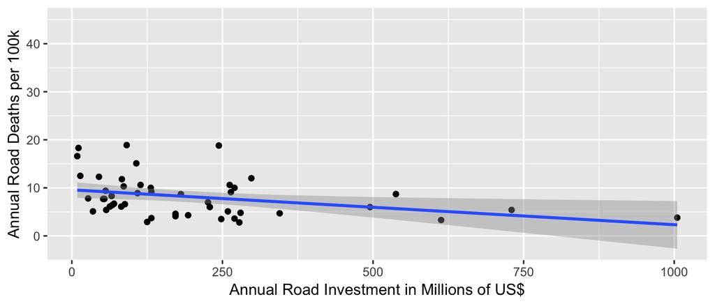

The more money spent on the roads, the higher the expectation that the roads are safe for travelers. In theory, spending reduces the number of imperfections in the roads, thereby reducing the external factors that could cause accidents to even the most cautious of drivers. The data suggests that higher amounts of rad spending do in fact decrease road mortality rates. The relationship is best demonstrated in Norway, Canada, and Australia, three coutnries with high amounts of road infrastructure investment and low rates of road deaths.

## 4.4 Road Deaths and Traffic Congestion

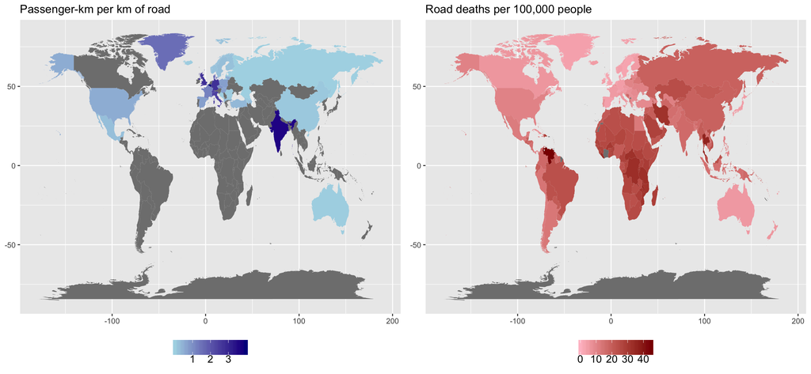

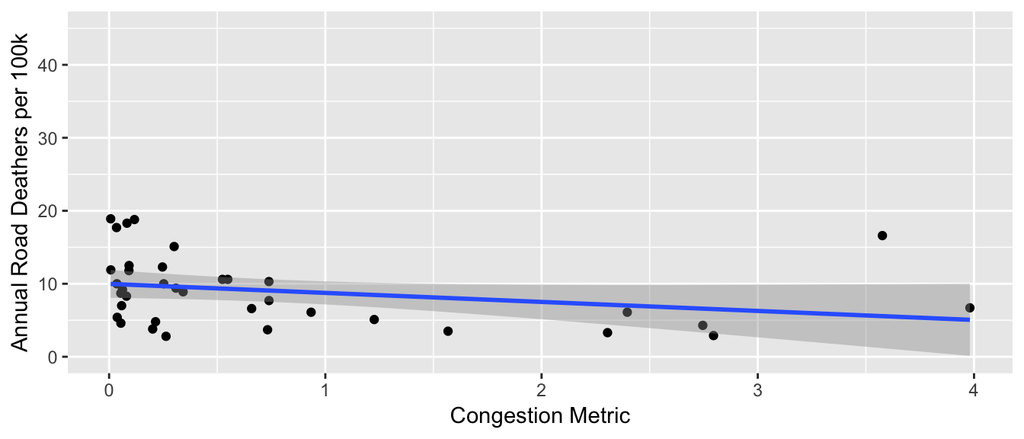

Figure 6: Top: Maps comparing congestion and rates of road death by country. Bottom: Scatter plot of congestion versus mortality rates. Sources: International Transportation Forum, Organization for Economic Co-operation and Development (2013 passenger-km), CIA World Factbook (km of road), and World Health Organization, 2013 (road deaths).

# 5 Conclusion

# References

[1] World Health Organization, http://apps.who.int/gho/data/view.main.51421

[2] International Transportation Forum, Organization for Economic Co-operation and Development https://stats.oecd.org/

[3] CIA World Factbook https://www.cia.gov/library/publications/the-world-factbook/